# Assignment 3, Task 2

Alessandra Puig-Santana

2023-03-02

# Introduction

In this task we use hierarchical clustering by complete linkage, single linkage, and and a tanglegram demonstrating multivariate clustering for water chemistry by site in the Santa Barbara Coastal Drainage Area collected by the Santa Barbara (SB) Coastal Long Term Ecological Research (LTER) Network. I did this by grouping each sampling site by their similarities with agglomerative hierarchical clustering.

The SB Coastal LTER collected information on the sampling site, the sampling date, and concentrations of different chemicals such as nitrates, ammonium, phosphates, and more. We visualize these groupings through dendrograms by the clustering algorithm and tanglegrams are created to show the differences between different dendrograms created.

```r
knitr::opts_chunk$set(echo = TRUE, message = FALSE, warning = FALSE)

# set up chunk

library(tidyverse)
library(here)
library(janitor)
library(ggdendro)
library(NbClust)
library(cluster)
library(factoextra)
library(dendextend)
```

```r
# read in data
stream_chem <- read_csv(here("data", "sbc_lter_registered_stream_chemistry.csv"))
```

```r
# Data Wrangling

stream_chem_clean <- stream_chem %>%
  clean_names() %>%
  na_if(-999) %>%
  drop_na() %>%
  select(-timestamp_local) %>%
  group_by(site_code) %>%
  summarize(nh4_u_m = mean(nh4_u_m),
            no3_u_m = mean(no3_u_m),
            po4_u_m = mean(po4_u_m),
            tdn_u_m = mean(tdn_u_m),
            tdp_u_m = mean(tdp_u_m),
            tpc_u_m = mean(tpc_u_m),
            tpn_u_m = mean(tpn_u_m),
            tpp_u_m = mean(tpp_u_m),
            tss_mgper_liter = mean(tss_mgper_liter),
            spec_cond_u_spercm = mean(spec_cond_u_spercm))

### scales the data to have a mean of 0
stream_chem_scale <- stream_chem_clean %>%
  select(!1:2) %>%
  scale()

## rownames become the site location
rownames(stream_chem_scale) <- stream_chem_clean$site_code
```

# Hierarchical clustering

## Complete linkage method

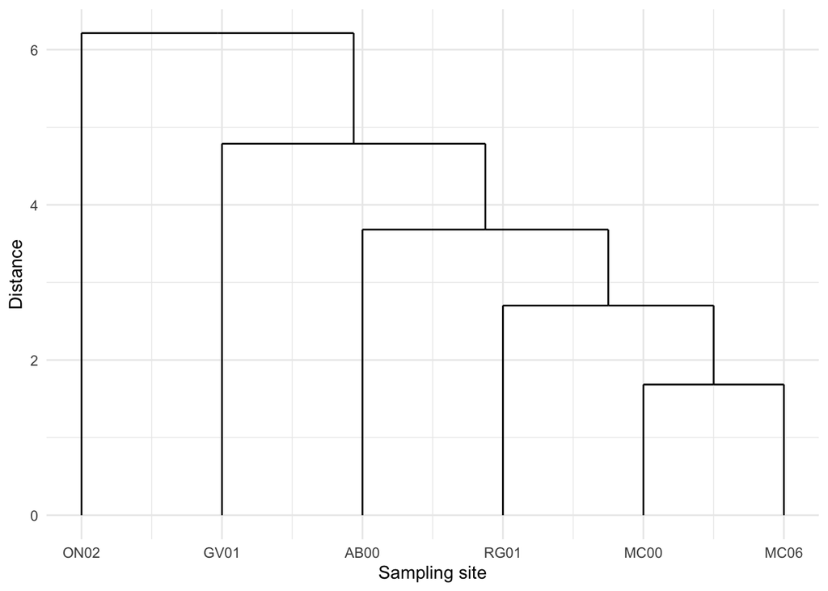

```r
## calculates the distance matrix
chem_dist <- dist(stream_chem_scale, method = 'euclidean')

### cluster analysis
chem_dist_hc <- hclust(chem_dist, method = 'complete')
chem_dist_min <- hclust(chem_dist, method = 'single')
chem_dist_w <- hclust(chem_dist, method = 'ward.D')

### dendogram creation
ggdendrogram(chem_dist_hc) +
  labs(x = 'Sampling site',
       y = 'Distance') +
  theme_minimal()
```

**Figure 1. Dendrogram** Complete linkage method